# 分布从哪里来：聚合的三种方式，和打破它的第四条路

最后更新：2026-07-25 21:49 EDT

自然界里的量，很少是”一次性”产生的：一个人的身高来自成百上千个基因和环境因素共同作用；一个城市的人口是几十年增长的累积；一次地震释放的能量来自无数微小滑移的连锁。**很多小贡献，合成一个观测量**——这是分布得以形成的最常见方式。

那么问题变得很具体：**这些小贡献是怎么”合成”的？** 答案出人意料地少。基本上只有三种：

| 合成方式 | 极限定理 | 得到的分布 |
| --- | --- | --- |
| **加** $\;\sum_i X_i$ | 中心极限定理 | 正态（重尾时 → Lévy 稳定律） |
| **乘** $\;\prod_i X_i$ | 取对数后用 CLT | 对数正态 |
| **取最大** $\;\max_i X_i$ | Fisher–Tippett–Gnedenko | Gumbel / Fréchet / Weibull |

三个算子，三个普适定理——**不管每个小贡献自己长什么样，合成的结果都只能落进这几族**。这也给了一个反过来用的读法：看到正态，猜”加”；看到对数正态，猜”乘”；看到 Gumbel，猜”取了最大值”。

**还有第四条路。** 幂律不在上面三个定理里。原因很实在：它**打破了这三个定理共同的前提**——独立、同分布、有限方差。优先增长（富者愈富）、乘性增长加托底、临界分枝，都能产出幂律。所以本文最后一部分单独讲它。

$$\text{很多小贡献}
\;\xrightarrow{\;+\;/\;\times\;/\;\max\;}\; \text{三大普适族}
\qquad\qquad \text{打破 i.i.d.} \;\longrightarrow\;
\text{幂律}$$

# 1 一台钉板：把”加”做成机器

先看一台真实存在的机器——**高尔顿钉板**（Galton board）。一颗小球从顶端落下，每碰到一颗钉子就随机往左或往右偏一点，穿过 $n$ 排钉子后掉进底部的格子里。

关键在于：每颗钉子就是一次 $\pm$ 半格的随机选择，而**小球最终落在哪个格子，等于这 $n$ 次选择的和**：

$$\text{落点} =
\sum_{i=1}^{n}\varepsilon_i, \qquad \varepsilon_i = \pm\tfrac12 \
\text{各半概率}$$

所以钉板不是一件”用来演示正态分布”的玩具——它是**加法算子的物理实现**。把它跑几十万次，底部堆出来的形状就必然是正态：

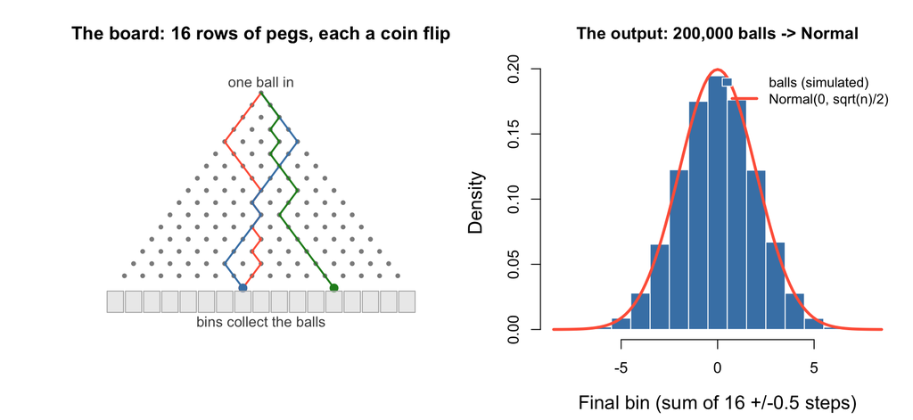

```r
n_layer <- 16
par(mfrow = c(1, 2), mar = c(4.4, 4.6, 3.6, 1))

## 左：钉板这台机器
plot(NA, xlim = c(-n_layer/2 - 1, n_layer/2 + 1), ylim = c(-n_layer - 3.4, 1.4),
     axes = FALSE, xlab = "", ylab = "",
     main = paste0("The board: ", n_layer, " rows of pegs, each a coin flip"))
for (i in 0:(n_layer - 1)) {                       # 钉子
  xs <- (0:i) - i/2
  points(xs, rep(-i, i + 1), pch = 16, col = "gray55", cex = 0.7)
}
cols_p <- c("tomato", "steelblue", "forestgreen")  # 三条球路
for (k in 1:3) {
  steps <- sample(c(-0.5, 0.5), n_layer, replace = TRUE)
  path_x <- c(0, cumsum(steps)); path_y <- 0:(-n_layer)
  lines(path_x, path_y, col = cols_p[k], lwd = 2)
  points(path_x[n_layer + 1], -n_layer, pch = 16, col = cols_p[k], cex = 1.3)
}
bins <- seq(-n_layer/2, n_layer/2, by = 1)         # 底部格子
rect(bins - 0.45, -n_layer - 2, bins + 0.45, -n_layer - 0.25,
     border = "gray70", col = adjustcolor("gray85", 0.5))
text(0, -n_layer - 2.75, "bins collect the balls", col = "gray30", cex = 0.95)
text(0, 0.9, "one ball in", col = "gray30", cex = 0.95)

## 右：很多球落下来的分布
n_ball <- 200000
pos <- rowSums(matrix(sample(c(-0.5, 0.5), n_ball * n_layer, replace = TRUE),
                      nrow = n_ball))
h <- hist(pos, breaks = seq(-n_layer/2 - 0.5, n_layer/2 + 0.5, by = 1), plot = FALSE)
plot(h, freq = FALSE, col = "steelblue", border = "white",
     main = paste0("The output: ", format(n_ball, big.mark = ",", scientific = FALSE),
                   " balls -> Normal"),
     xlab = "Final bin (sum of 16 +/-0.5 steps)", ylab = "Density",
     cex.lab = 1.25, cex.main = 1.1)
curve(dnorm(x, 0, sqrt(n_layer * 0.25)), add = TRUE, col = "tomato", lwd = 3)
legend("topright", c("balls (simulated)", "Normal(0, sqrt(n)/2)"),
       fill = c("steelblue", NA), border = c("white", NA),
       col = c(NA, "tomato"), lwd = c(NA, 3), bty = "n", cex = 0.9)
```

理论曲线（红）不需要拟合任何参数：$n$ 排钉子、每排方差 $1/4$，落点方差就是 $n/4$，标准差 $\sqrt{n}/2$。**机器的结构直接决定了输出分布的参数。**

这台机器也给了全文的路线图：**如果把钉板的规则从”加”换成”乘”、换成”取最大”，会掉出什么分布？** 这就是接下来三根柱子。

# 2 柱一：加——很多小量相加 → 正态

## 2.1 中心极限定理（CLT）

**不管原始分布是什么形状**，只要有有限方差，大量独立样本的均值趋向正态。

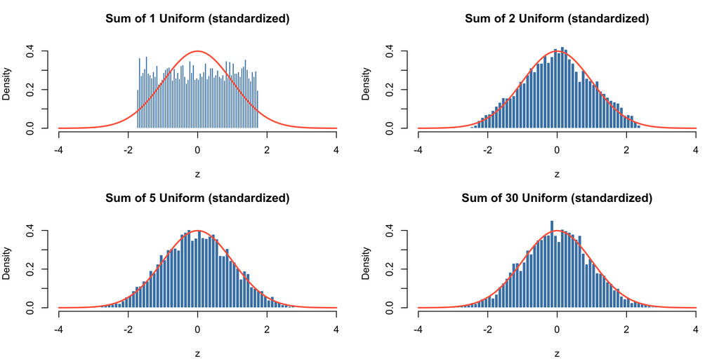

```r
ns <- c(1, 2, 5, 30)

par(mfrow = c(2, 2), mar = c(4, 4, 3, 1))
for (n in ns) {
  sums <- replicate(5000, sum(runif(n)))
  z    <- (sums - n * 0.5) / sqrt(n / 12)

  hist(z, breaks = 60, col = "steelblue", freq = FALSE, border = "white",
       main = paste0("Sum of ", n, " Uniform (standardized)"),
       xlab = "z", xlim = c(-4, 4), ylim = c(0, 0.46))
  curve(dnorm(x), add = TRUE, col = "tomato", lwd = 2)
}
```

### 2.1.1 CLT 与原始分布无关

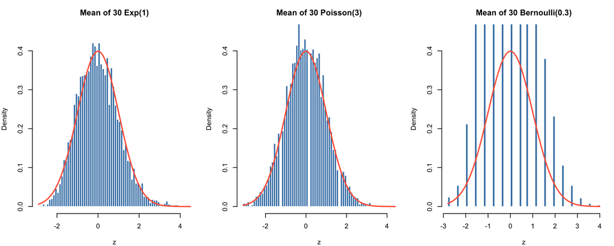

```r
n <- 30; M <- 5000
par(mfrow = c(1, 3), mar = c(4, 4, 3, 1))

# Exponential (heavy right skew)
z_exp <- scale(replicate(M, mean(rexp(n, 1))))
hist(z_exp, breaks = 60, col = "steelblue", freq = FALSE, border = "white",
     main = "Mean of 30 Exp(1)", xlab = "z", ylim = c(0, 0.45))
curve(dnorm(x), add = TRUE, col = "tomato", lwd = 2)

# Poisson (discrete)
z_pois <- scale(replicate(M, mean(rpois(n, 3))))
hist(z_pois, breaks = 60, col = "steelblue", freq = FALSE, border = "white",
     main = "Mean of 30 Poisson(3)", xlab = "z", ylim = c(0, 0.45))
curve(dnorm(x), add = TRUE, col = "tomato", lwd = 2)

# Bernoulli (extreme skew)
z_bern <- scale(replicate(M, mean(rbinom(n, 1, 0.3))))
hist(z_bern, breaks = 60, col = "steelblue", freq = FALSE, border = "white",
     main = "Mean of 30 Bernoulli(0.3)", xlab = "z", ylim = c(0, 0.45))
curve(dnorm(x), add = TRUE, col = "tomato", lwd = 2)
```

## 2.2 泊松过程：Exp 与 Poisson 的双面

同一个物理过程（事件以恒定速率 $\lambda$ 随机到达）同时产生两种分布：

- **数事件**（固定时间窗）→ Poisson($\lambda t$)
- **量间隔**（相邻事件）→ Exp($\lambda$)

两者共享同一个参数 $\lambda$。

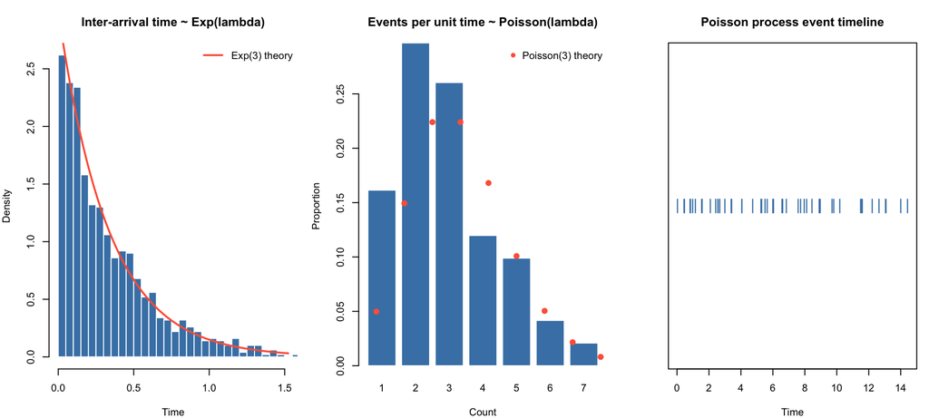

```r
lambda    <- 3
T_total   <- 200
n_arr     <- rpois(1, lambda * T_total) * 3
inter     <- rexp(n_arr, rate = lambda)
arrivals  <- cumsum(inter)
arrivals  <- arrivals[arrivals <= T_total]

par(mfrow = c(1, 3), mar = c(4, 4, 3.5, 1))

# Inter-arrival times → Exp
hist(inter[1:1000], breaks = 60, col = "steelblue", freq = FALSE,
     border = "white",
     main = "Inter-arrival time ~ Exp(lambda)", xlab = "Time",
     xlim = c(0, quantile(inter, 0.99)))
curve(dexp(x, rate = lambda), add = TRUE, col = "tomato", lwd = 2)
legend("topright", "Exp(3) theory", col = "tomato", lwd = 2, bty = "n")

# Counts per unit time → Poisson
counts <- tabulate(ceiling(arrivals[arrivals > 0]))
counts <- counts[counts > 0]
tbl    <- table(counts) / length(counts)
barplot(tbl, col = "steelblue", border = "white",
        main = "Events per unit time ~ Poisson(lambda)",
        xlab = "Count", ylab = "Proportion")
k_vals <- 0:12
points(k_vals + 0.5, dpois(k_vals, lambda),
       col = "tomato", pch = 16, cex = 1.3)
legend("topright", "Poisson(3) theory", col = "tomato", pch = 16, bty = "n")

# Timeline
n_show <- min(50, length(arrivals))
plot(arrivals[1:n_show], rep(1, n_show),
     pch = "|", cex = 1.5, col = "steelblue",
     main = "Poisson process event timeline", xlab = "Time",
     ylab = "", yaxt = "n", ylim = c(0.5, 1.5))
```

## 2.3 k 个 Exp 求和 → Gamma

等待第 $k$ 个事件 = 等 $k$ 段间隔之和 → $\text{Gamma}(k, \lambda)$。

这是 Gamma 分布最直接的物理意义：**泊松过程中，第 $k$ 次事件发生的时刻。**

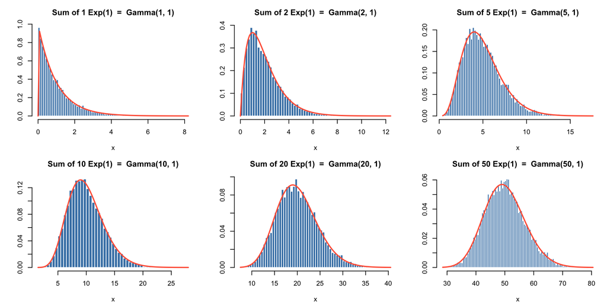

```r
n_sim <- 10000
par(mfrow = c(2, 3), mar = c(4, 4, 3, 1))
for (k in c(1, 2, 5, 10, 20, 50)) {
  sums <- rowSums(matrix(rexp(n_sim * k, rate = 1), nrow = n_sim))
  hist(sums, breaks = 80, col = "steelblue", freq = FALSE, border = "white",
       main = paste0("Sum of ", k, " Exp(1)  =  Gamma(", k, ", 1)"),
       xlab = "x", ylab = "")
  curve(dgamma(x, shape = k, rate = 1), add = TRUE, col = "tomato", lwd = 2)
}
```

注意 $k$ 增大时 Gamma 趋向正态——CLT 再次生效。

精确的包含关系：**Exp($\lambda$) = Gamma(1, $\lambda$)**。

[figure not shown]

```r
par(mfrow = c(1, 2), mar = c(4, 4, 3.5, 1))

x_seq <- seq(0.01, 6, length.out = 500)
plot(x_seq, dgamma(x_seq, shape = 1, rate = 1), type = "l",
     col = "steelblue", lwd = 3,
     main = "Exp(lambda) = Gamma(1, lambda)\n(exact equivalence)",
     xlab = "x", ylab = "Density")
lines(x_seq, dexp(x_seq, rate = 1), col = "tomato", lwd = 2, lty = 2)
legend("topright", c("Gamma(1,1)", "Exp(1)"),
       col = c("steelblue", "tomato"), lwd = 2, lty = c(1, 2), bty = "n")

# Gamma family
cols_g <- c("steelblue", "green3", "orange", "red", "purple")
plot(NA, xlim = c(0, 12), ylim = c(0, 0.5),
     main = "Gamma(k, 1) family", xlab = "x", ylab = "Density")
for (i in seq_along(c(1, 2, 5, 10, 20))) {
  k <- c(1, 2, 5, 10, 20)[i]
  lines(x_seq, dgamma(seq(0.01, 12, length.out = 500), k, 1),
        col = cols_g[i], lwd = 2)
}
legend("topright", paste("shape =", c(1,2,5,10,20)),
       col = cols_g, lwd = 2, bty = "n")
```

## 2.4 k 个 Normal² 求和 → Chi-squared

若 $Z_1, \ldots, Z_k \overset{\text{iid}}{\sim} N(0,1)$，则：

$$\chi^2_k = \sum_{i=1}^k Z_i^2 \sim
\chi^2(k) = \text{Gamma}\!\left(\frac{k}{2},\,
\frac{1}{2}\right)$$

**精确等价**：Chi-squared 是 Gamma 分布的特例。这意味着求和这一节的所有分布最终都汇聚到 Gamma：

- Exp = Gamma(1, $\lambda$)
- $k$ 个 Exp 之和 = Gamma($k$, $\lambda$)
- Chi-squared($k$) = Gamma($k/2$, $1/2$)
- $k \to \infty$ 时 Gamma → Normal（CLT 闭环）

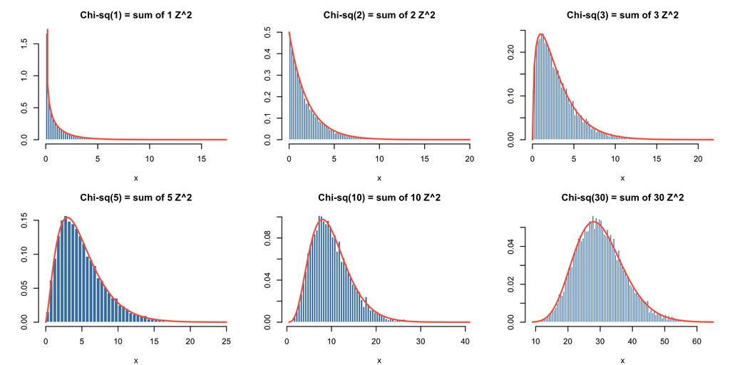

```r
n_sim <- 10000
par(mfrow = c(2, 3), mar = c(4, 4, 3, 1))
for (k in c(1, 2, 3, 5, 10, 30)) {
  Z    <- matrix(rnorm(n_sim * k), nrow = n_sim)
  chi2 <- rowSums(Z^2)
  hist(chi2, breaks = 80, col = "steelblue", freq = FALSE, border = "white",
       main = paste0("Chi-sq(", k, ") = sum of ", k, " Z^2"),
       xlab = "x", ylab = "")
  curve(dchisq(x, df = k), add = TRUE, col = "tomato", lwd = 2)
}
```

## 2.5 求和小结

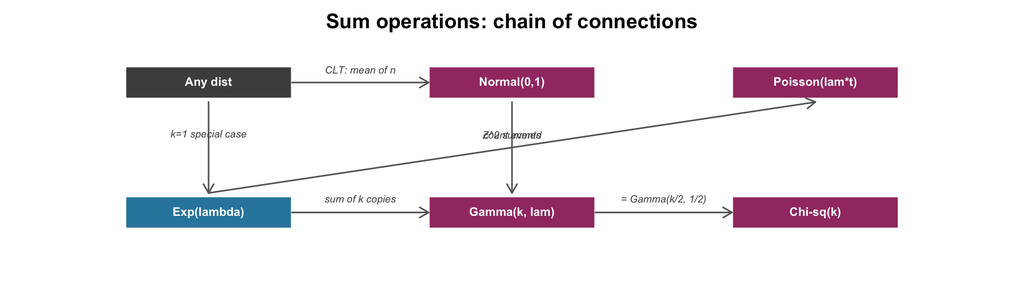

```r
par(mar = c(1, 1, 2, 1))
plot(NA, xlim = c(0, 12), ylim = c(0, 3.5), axes = FALSE, bty = "n",
     xlab = "", ylab = "", main = "Sum operations: chain of connections")

draw_box <- function(x, y, label, col, w = 2.2, h = 0.5) {
  rect(x-w/2, y-h/2, x+w/2, y+h/2, col = col, border = "white", lwd = 2)
  text(x, y, label, col = "white", font = 2, cex = 0.7)
}
arr <- function(x0, y0, x1, y1, lab = "") {
  arrows(x0, y0, x1, y1, length = 0.10, lwd = 1.5, col = "gray40")
  text((x0+x1)/2, (y0+y1)/2 + 0.2, lab, cex = 0.6, col = "gray30", font = 3)
}

draw_box(2,   3, "Any dist",     "gray30")
draw_box(6,   3, "Normal(0,1)",  "#A23B72")
draw_box(2,   1, "Exp(lambda)",  "#2E86AB")
draw_box(6,   1, "Gamma(k, lam)","#A23B72")
draw_box(10,  1, "Chi-sq(k)",    "#A23B72")
draw_box(10,  3, "Poisson(lam*t)","#A23B72")

arr(3.1, 3, 4.9, 3, "CLT: mean of n")
arr(2,   2.7, 2,   1.3, "k=1 special case")
arr(3.1, 1, 4.9, 1, "sum of k copies")
arr(6,   2.7, 6,   1.3, "Z^2 summed")
arr(7.1, 1, 8.9, 1, "= Gamma(k/2, 1/2)")
arr(2,   1.3, 10,  2.7, "count events")
```

# 3 柱二：乘——很多因子相乘 → 对数正态

把钉板的规则改一个字：每碰到一颗钉子，不是**加**减半格，而是**乘**上一个随机因子。

这不是数学游戏。现实里大量的量本来就是乘性累积的：投资收益按百分比复利、细胞按倍数分裂、城市人口按增长率逐年扩张、颗粒在破碎中每次损失一定比例。这些过程里，“再增长 10%” 比 “再增加 10 个单位” 更自然。

$$\text{乘性钉板：}\quad X =
\prod_{i=1}^{n} f_i \qquad\text{（每个 } f_i>0 \text{
是随机因子）}$$

**取一次对数，乘就变成加：**

$$\ln X = \sum_{i=1}^{n} \ln
f_i$$

右边是一串独立小量的**和**——柱一的 CLT 立刻适用。于是 $\ln X$ 趋于正态，而 $X$ 本身服从**对数正态分布**：

$$\ln X \sim \text{Normal}(\mu, \sigma^2)
\quad\Longleftrightarrow\quad X \sim \text{LogNormal}(\mu,
\sigma^2)$$

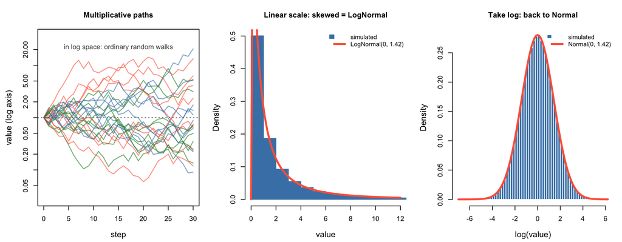

```r
n_step <- 30; a <- 0.45              # 每步乘 exp(eps), eps ~ Uniform(-a, a)
sd_log <- a / sqrt(3) * sqrt(n_step)
par(mfrow = c(1, 3), mar = c(4.4, 4.6, 3.6, 1))

## 1) 乘性轨迹（log 纵轴）
plot(NA, xlim = c(0, n_step), ylim = c(exp(-3.6), exp(3.6)), log = "y",
     main = "Multiplicative paths", xlab = "step", ylab = "value (log axis)",
     cex.lab = 1.2, cex.main = 1.1)
for (k in 1:25) {
  lines(0:n_step, exp(c(0, cumsum(runif(n_step, -a, a)))),
        col = adjustcolor(c("tomato","steelblue","forestgreen")[1 + k %% 3], 0.6), lwd = 1.4)
}
abline(h = 1, col = "gray40", lty = 3)
text(n_step/2, exp(3.1), "in log space: ordinary random walks", col = "gray30", cex = 1.0)

## 2) 线性尺度 → 右偏（对数正态）
n_path <- 200000
logv <- rowSums(matrix(runif(n_path * n_step, -a, a), nrow = n_path))
val  <- exp(logv)
hist(val, breaks = 600, freq = FALSE, col = "steelblue", border = "steelblue",
     xlim = c(0, 12), main = "Linear scale: skewed = LogNormal",
     xlab = "value", ylab = "Density", cex.lab = 1.2, cex.main = 1.1)
curve(dlnorm(x, 0, sd_log), add = TRUE, col = "tomato", lwd = 3)
legend("topright", c("simulated", paste0("LogNormal(0, ", round(sd_log, 2), ")")),
       fill = c("steelblue", NA), border = c("steelblue", NA),
       col = c(NA, "tomato"), lwd = c(NA, 3), bty = "n", cex = 0.9)

## 3) 取对数 → 正态
hist(logv, breaks = 80, freq = FALSE, col = "steelblue", border = "white",
     main = "Take log: back to Normal", xlab = "log(value)", ylab = "Density",
     cex.lab = 1.2, cex.main = 1.1)
curve(dnorm(x, 0, sd_log), add = TRUE, col = "tomato", lwd = 3)
legend("topright", c("simulated", paste0("Normal(0, ", round(sd_log, 2), ")")),
       fill = c("steelblue", NA), border = c("white", NA),
       col = c(NA, "tomato"), lwd = c(NA, 3), bty = "n", cex = 0.9)
```

注意模拟里每个因子的对数取的是**均匀分布**，不是正态——但合成 30 步后，$\ln X$ 依然精准贴合正态（右图）。这正是普适性：**单个因子长什么样不重要，重要的是它们被”乘”在一起。**

中间那张图值得多看一眼：同一批数据在线性尺度上是**强右偏**的——大多数值挤在左边，少数很大的值拖出长尾。这是乘性过程的签名，也是现实数据里”平均值远大于中位数”的常见来源（对数正态的中位数是 $e^{\mu}$，均值是 $e^{\mu+\sigma^2/2}$，后者总是更大）。

**一个要紧的提醒**：纯乘性增长给出的是**对数正态，不是幂律**。这两者都重尾、在有限数据上还常常难以区分，但机制不同——“乘法增长必然产生幂律”是一句流传很广的错话。要从乘性过程得到幂律，还需要额外的东西（一个下界托底、或者按规模优先增长），这正是第四条路要讲的。

# 4 柱三：取最大——只看最大的那个 → 极值三族

## 4.1 次序统计量 → Beta

若 $X_1, \ldots, X_n \overset{\text{iid}}{\sim} \text{Uniform}(0,1)$，则第 $k$ 小的样本：

$$X_{(k)} \sim \text{Beta}(k,\,
n-k+1)$$

**推导**（以最大值为例）：$P(X_{(n)} \leq x) = P(\text{all} \leq x) = x^n$，求导得 $f(x) = nx^{n-1}$，即 Beta(n,1)。

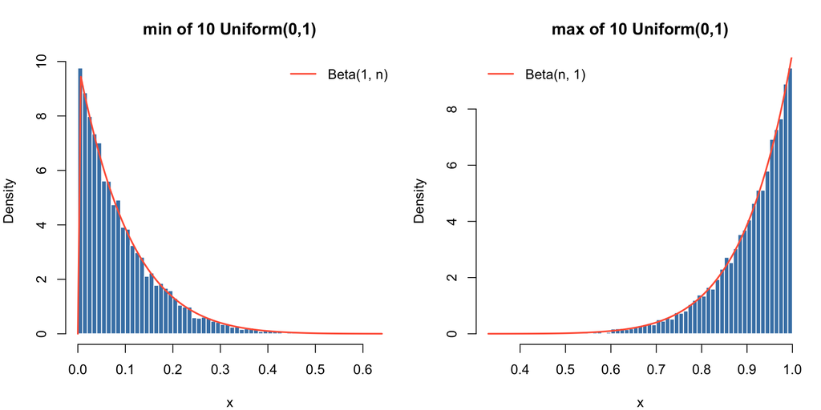

```r
n <- 10; n_sim <- 10000
M       <- matrix(runif(n_sim * n), nrow = n_sim, ncol = n)
row_min <- apply(M, 1, min)
row_max <- apply(M, 1, max)

par(mfrow = c(1, 2), mar = c(4, 4, 3.5, 1))

hist(row_min, breaks = 60, col = "steelblue", freq = FALSE, border = "white",
     main = paste0("min of ", n, " Uniform(0,1)"), xlab = "x")
curve(dbeta(x, 1, n), add = TRUE, col = "tomato", lwd = 2)
legend("topright", "Beta(1, n)", col = "tomato", lwd = 2, bty = "n")

hist(row_max, breaks = 60, col = "steelblue", freq = FALSE, border = "white",
     main = paste0("max of ", n, " Uniform(0,1)"), xlab = "x")
curve(dbeta(x, n, 1), add = TRUE, col = "tomato", lwd = 2)
legend("topleft", "Beta(n, 1)", col = "tomato", lwd = 2, bty = "n")
```

### 4.1.1 一般次序统计量

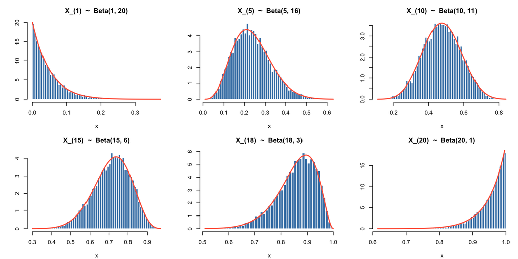

```r
n <- 20; n_sim <- 10000
M_sorted <- t(apply(matrix(runif(n_sim * n), nrow = n_sim), 1, sort))

par(mfrow = c(2, 3), mar = c(4, 4, 3, 1))
for (k in c(1, 5, 10, 15, 18, 20)) {
  hist(M_sorted[, k], breaks = 60, col = "steelblue", freq = FALSE,
       border = "white",
       main = paste0("X_(", k, ")  ~  Beta(", k, ", ", n-k+1, ")"),
       xlab = "x", ylab = "")
  curve(dbeta(x, k, n - k + 1), add = TRUE, col = "tomato", lwd = 2)
}
```

## 4.2 极值分布：大量样本的最大值

### 4.2.1 Fisher-Tippett-Gnedenko 定理

对 $n$ 个 i.i.d. 样本的最大值，经适当线性标准化后，只能收敛到三种分布之一：

| Type | Name | Tail of original | Example |
| --- | --- | --- | --- |
| I | Gumbel | Light tail (exp decay) | Normal, Gamma, Exp |
| II | Frechet | Heavy tail (power law) | Pareto, t dist |
| III | Weibull (extreme) | Bounded support | Uniform, Beta |

```r
# Hand-implement Gumbel (no extra package needed)
dgumbel <- function(x, mu = 0, beta = 1) {
  z <- (x - mu) / beta
  (1/beta) * exp(-(z + exp(-z)))
}
pgumbel <- function(x, mu = 0, beta = 1) {
  exp(-exp(-(x - mu) / beta))
}
```

### 4.2.2 正态最大值 → Gumbel

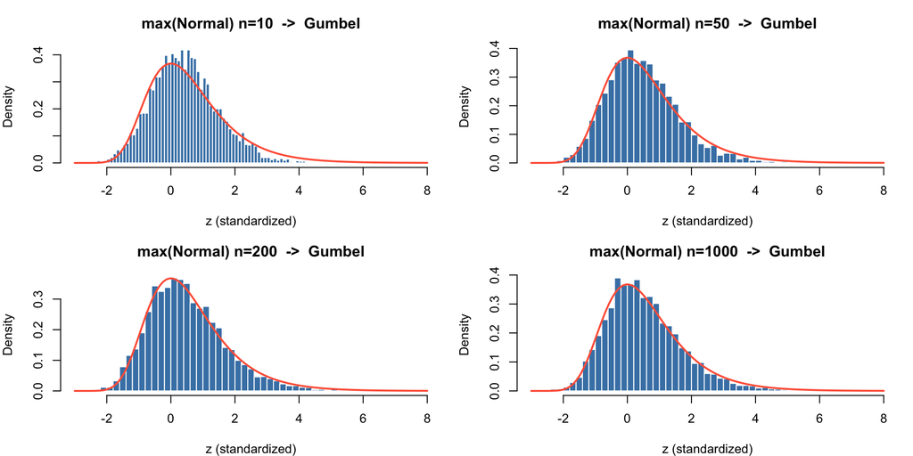

```r
n_sim <- 5000
par(mfrow = c(2, 2), mar = c(4, 4, 3, 1))
for (n in c(10, 50, 200, 1000)) {
  max_vals <- replicate(n_sim, max(rnorm(n)))
  b_n      <- qnorm(1 - 1/n)
  a_n      <- 1 / (n * dnorm(b_n))
  z        <- (max_vals - b_n) / a_n

  hist(z, breaks = 60, col = "steelblue", freq = FALSE, border = "white",
       main = paste0("max(Normal) n=", n, "  ->  Gumbel"),
       xlab = "z (standardized)", xlim = c(-3, 8))
  curve(dgumbel(x), add = TRUE, col = "tomato", lwd = 2)
}
```

### 4.2.3 不同尾部 → 不同极值族

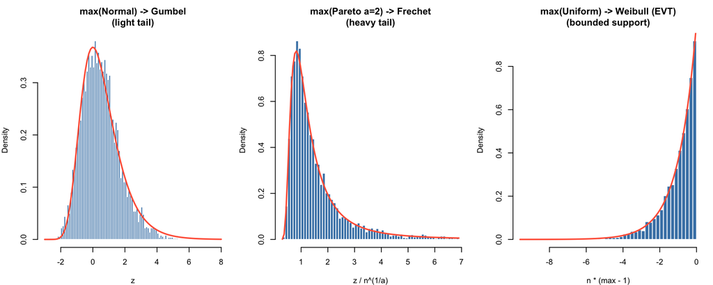

```r
n     <- 200
n_sim <- 5000
par(mfrow = c(1, 3), mar = c(4, 4, 3.5, 1))

# I. Normal → Gumbel (light tail)
max_norm <- replicate(n_sim, max(rnorm(n)))
b_n <- qnorm(1 - 1/n); a_n <- 1/(n * dnorm(b_n))
z_norm <- (max_norm - b_n) / a_n
hist(z_norm, breaks = 60, col = "steelblue", freq = FALSE, border = "white",
     main = "max(Normal) -> Gumbel\n(light tail)",
     xlab = "z", xlim = c(-3, 8))
curve(dgumbel(x), add = TRUE, col = "tomato", lwd = 2)

# II. Pareto(2) → Frechet (heavy tail)
max_pareto <- replicate(n_sim, max((1-runif(n))^(-1/2)))
a_n_p <- n^(1/2)
z_pareto <- max_pareto / a_n_p
z_pareto_trim <- z_pareto[z_pareto < quantile(z_pareto, 0.98)]
hist(z_pareto_trim, breaks = 60, col = "steelblue", freq = FALSE,
     border = "white",
     main = "max(Pareto a=2) -> Frechet\n(heavy tail)",
     xlab = "z / n^(1/a)")
frechet_density <- function(x, alpha = 2) {
  alpha * x^(-(alpha+1)) * exp(-x^(-alpha))
}
curve(frechet_density(x), add = TRUE, col = "tomato", lwd = 2)

# III. Uniform → Weibull (bounded)
max_unif <- replicate(n_sim, max(runif(n)))
z_unif   <- n * (max_unif - 1)
hist(z_unif, breaks = 60, col = "steelblue", freq = FALSE, border = "white",
     main = "max(Uniform) -> Weibull (EVT)\n(bounded support)",
     xlab = "n * (max - 1)")
curve(exp(x) * (x <= 0), add = TRUE, col = "tomato", lwd = 2)
```

# 5 第四条路：打破 i.i.d. → 幂律

三根柱子背后是三个极限定理，而这三个定理都建立在同一组前提上：小贡献**相互独立**、**同分布**、**方差有限**。前提成立，结果就只能落进正态／对数正态／极值三族——**幂律不在其中**。

反过来说，想得到幂律，就得破坏这组前提。破坏的方式很具体，而且它们有个共同点：**引入反馈**——让增长依赖于当前状态，于是各次贡献不再独立同分布。下面看三种最常见的反馈。

## 5.1 机制一：优先增长（富者愈富）

规则简单到几乎像作弊：系统每一步长大一个单位，这个单位**按当前规模正比地**分给已有成员；偶尔（概率 $\alpha$）诞生一个规模为 1 的新成员。

$$P(\text{增量给成员 } i) \;\propto\; S_i
\qquad\text{（Simon 1955；网络版即 Barabási–Albert）}$$

已经大的更容易变大——这就是反馈。稳态规模分布是幂律，密度指数有闭式解：

$$\lambda = 1 +
\frac{1}{1-\alpha}$$

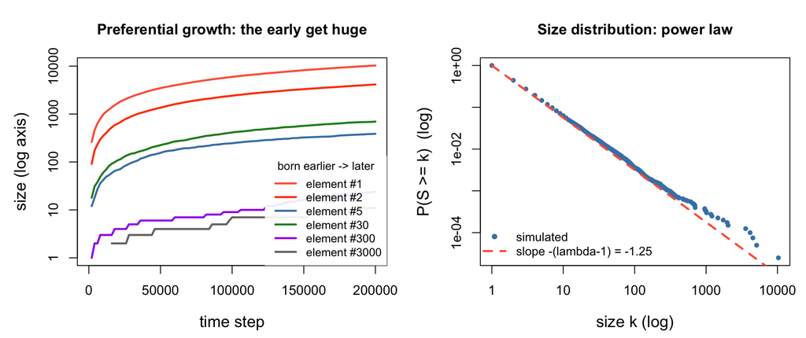

```r
## Simon 优先增长：每步以概率 alpha 诞生新元素，否则按当前规模正比地长大
alpha <- 0.2; n_steps <- 200000
owner <- integer(n_steps); sizes <- integer(n_steps)
n_elem <- 0L; n_unit <- 0L
u1 <- runif(n_steps); u2 <- runif(n_steps)
track <- c(1L, 2L, 5L, 30L, 300L, 3000L)          # 出生越来越晚的 6 个元素
chk <- seq(2000, n_steps, by = 2000)
hist_mat <- matrix(NA_real_, nrow = length(chk), ncol = length(track))
ci <- 1L
for (t in seq_len(n_steps)) {
  if (u1[t] < alpha || n_unit == 0L) {
    n_elem <- n_elem + 1L; sizes[n_elem] <- 1L
    n_unit <- n_unit + 1L; owner[n_unit] <- n_elem
  } else {
    j <- owner[ceiling(u2[t] * n_unit)]
    sizes[j] <- sizes[j] + 1L
    n_unit <- n_unit + 1L; owner[n_unit] <- j
  }
  if (ci <= length(chk) && t == chk[ci]) {
    hist_mat[ci, ] <- ifelse(track <= n_elem, sizes[track], NA_real_); ci <- ci + 1L
  }
}
S <- sizes[1:n_elem]

par(mfrow = c(1, 2), mar = c(4.5, 4.8, 3.6, 1))

## 左：被跟踪元素的成长轨迹——先来的越滚越大
cols_t <- c("tomato","orangered","steelblue","forestgreen","purple","gray45")
plot(NA, xlim = c(0, n_steps), ylim = c(1, max(S)), log = "y",
     main = "Preferential growth: the early get huge",
     xlab = "time step", ylab = "size (log axis)", cex.lab = 1.2, cex.main = 1.1)
for (k in seq_along(track))
  lines(chk, hist_mat[, k], col = cols_t[k], lwd = 2.4)
legend("bottomright", paste0("element #", track), col = cols_t, lwd = 2.4,
       cex = 0.85, title = "born earlier -> later",
       bg = adjustcolor("white", 0.9), box.col = NA)

## 右：最终规模分布，log-log 上一条直线
tab <- sort(unique(S)); surv <- sapply(tab, function(k) mean(S >= k))
lam <- 1 + 1/(1 - alpha)                            # 理论密度指数
plot(tab, surv, log = "xy", pch = 16, col = "steelblue", cex = 0.8,
     main = "Size distribution: power law", xlab = "size k (log)",
     ylab = "P(S >= k)  (log)", cex.lab = 1.2, cex.main = 1.1)
kk <- 10^seq(0, log10(max(tab)), length.out = 50)
lines(kk, kk^(-(lam - 1)), col = "tomato", lwd = 2.5, lty = 2)
legend("bottomleft", c("simulated", sprintf("slope -(lambda-1) = %.2f", -(lam-1))),
       col = c("steelblue","tomato"), pch = c(16, NA), lwd = c(NA, 2.5),
       lty = c(NA, 2), bty = "n", cex = 0.9)
```

## 5.2 机制二：乘性增长 + 托底（Kesten）

柱二说过：**纯**乘性增长给的是对数正态。差别只在一件事——加一个**下界托底**：

$$W_{t+1} = A_t W_t + B_t, \qquad B_t >
0$$

$A_t$ 是随机增长因子（乘性涨落），$B_t$ 是每期注入的固定量（工资收入、最低保障、新流入）。托底让财富掉不到零，于是过程不再无限扩散、而是收敛到一个**稳态分布**——这个稳态的上尾是幂律。尾指数 $\alpha$ 由下式定：

$$E[A^{\alpha}] = 1 \qquad(\text{同时要求
} E[\ln A] < 0 \text{，否则会无限膨胀})$$

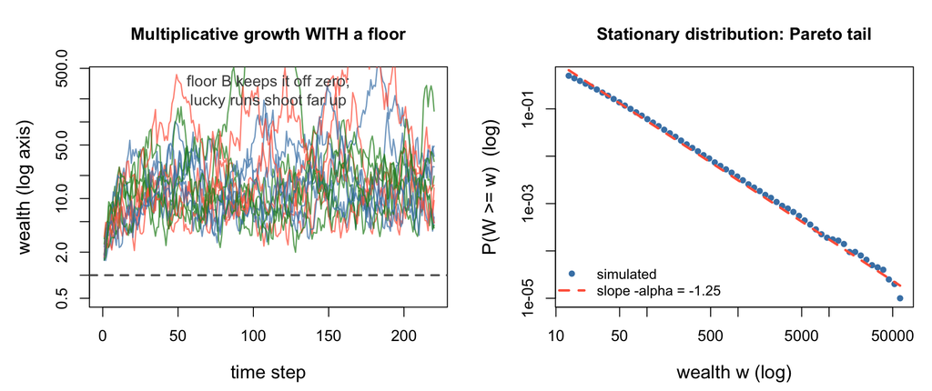

```r
mu_a <- -0.1; s_a <- 0.4; B <- 1          # W <- A*W + B,  A = exp(N(mu,s^2))
alpha <- -2*mu_a/s_a^2                     # E[A^alpha]=1 的解 -> 尾指数
par(mfrow = c(1, 2), mar = c(4.5, 4.8, 3.6, 1))

## 左：几条轨迹——乘性涨落 + 每期托底注入
T1 <- 220
plot(NA, xlim = c(0, T1), ylim = c(0.5, 400), log = "y",
     main = "Multiplicative growth WITH a floor", xlab = "time step",
     ylab = "wealth (log axis)", cex.lab = 1.2, cex.main = 1.1)
for (k in 1:14) {
  w <- 1; path <- numeric(T1)
  for (t in 1:T1) { w <- exp(rnorm(1, mu_a, s_a)) * w + B; path[t] <- w }
  lines(1:T1, path, col = adjustcolor(c("tomato","steelblue","forestgreen")[1 + k %% 3], 0.7), lwd = 1.4)
}
abline(h = B, col = "gray35", lty = 2, lwd = 2)
text(T1/2, 260, "floor B keeps it off zero;\nlucky runs shoot far up", col = "gray30", cex = 1.0)

## 右：稳态分布 -> 幂律尾
n_ch <- 200000; T2 <- 400
W <- rep(1, n_ch)
for (t in 1:T2) W <- exp(rnorm(n_ch, mu_a, s_a)) * W + B
tab <- 10^seq(log10(quantile(W, 0.5)), log10(quantile(W, 0.99999)), length.out = 60)
surv <- sapply(tab, function(k) mean(W >= k))
plot(tab, surv, log = "xy", pch = 16, col = "steelblue", cex = 0.9,
     main = "Stationary distribution: Pareto tail", xlab = "wealth w (log)",
     ylab = "P(W >= w)  (log)", cex.lab = 1.2, cex.main = 1.1)
ref <- tab[8]; lines(tab, surv[8] * (tab/ref)^(-alpha), col = "tomato", lwd = 2.5, lty = 2)
legend("bottomleft", c("simulated", sprintf("slope -alpha = %.2f", -alpha)),
       col = c("steelblue","tomato"), pch = c(16, NA), lwd = c(NA, 2.5),
       lty = c(NA, 2), bty = "n", cex = 0.9)
```

同一批乘性涨落，只多了一条”掉不下去的地板”，尾巴就从对数正态变成了 Pareto（右图斜率 $-\alpha=-1.25$，与 $E[A^\alpha]=1$ 的解一致）。这也解释了财富数据常见的样子：**主体近似对数正态，高阈值以上才接近 Pareto 尾**。

## 5.3 机制三：临界分枝

第三种反馈来自**随机个数的求和**。一个个体产生随机个后代，后代再产生后代，直到谱系终止；总产出 $T$ 是一个”随机停时之前的和”，而不是固定 $n$ 项的和——柱一的 CLT 不适用。

当分裂与终止**恰好平衡**（后代数均值 $=1$，即**临界**）时，总产出的分布是幂律：

$$P(T = t) \;\propto\;
t^{-3/2}$$

稍微偏离临界，尾部立刻被指数截断（变成”幂律核 × 指数尾”）。神经雪崩、森林火灾规模、流行病早期簇的大小，都常用临界分枝解释。这里的要点是：**幂律出现在参数恰好调到临界点时**，而某些耗散系统会自己滚到临界点上（自组织临界）。

## 5.4 读出指数：尾部对比、Hill 估计与矩的存在性

### 5.4.1 指数尾 vs 幂律尾

**指数尾**：$P(X > x) \sim e^{-\lambda x}$，下降极快。 **幂律尾**：$P(X > x) \sim x^{-\alpha}$，下降缓慢，极端值远比直觉频繁。

在**对数-对数坐标**下，幂律尾部呈直线（斜率 $= -\alpha$）。

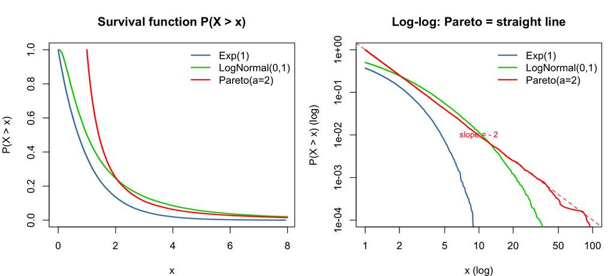

```r
n_sim <- 50000
alpha <- 2

x_exp    <- rexp(n_sim, 1)
x_lnorm  <- rlnorm(n_sim, 0, 1)
x_pareto <- (1 - runif(n_sim))^(-1/alpha)

ecdf_sf <- function(x) {
  x_sorted <- sort(x)
  sf       <- 1 - (1:length(x)) / length(x)
  list(x = x_sorted, sf = sf)
}
sf_exp    <- ecdf_sf(x_exp)
sf_lnorm  <- ecdf_sf(x_lnorm)
sf_pareto <- ecdf_sf(x_pareto)

par(mfrow = c(1, 2), mar = c(4, 4, 3.5, 1))

# Linear scale
plot(sf_exp$x[sf_exp$x < 8], sf_exp$sf[sf_exp$x < 8],
     type = "l", col = "steelblue", lwd = 2,
     main = "Survival function P(X > x)", xlab = "x", ylab = "P(X > x)")
lines(sf_lnorm$x[sf_lnorm$x < 8], sf_lnorm$sf[sf_lnorm$x < 8],
      col = "green3", lwd = 2)
lines(sf_pareto$x[sf_pareto$x < 8], sf_pareto$sf[sf_pareto$x < 8],
      col = "red", lwd = 2)
legend("topright", c("Exp(1)", "LogNormal(0,1)", paste0("Pareto(a=", alpha, ")")),
       col = c("steelblue","green3","red"), lwd = 2, bty = "n")

# Log-log: Pareto becomes a straight line
x_range <- c(1, 100)
idx_e <- sf_exp$x > 1
idx_l <- sf_lnorm$x > 1
idx_p <- sf_pareto$x > 1

plot(sf_exp$x[idx_e], sf_exp$sf[idx_e],
     type = "l", col = "steelblue", lwd = 2, log = "xy",
     main = "Log-log: Pareto = straight line",
     xlab = "x (log)", ylab = "P(X > x) (log)",
     xlim = x_range, ylim = c(1e-4, 1))
lines(sf_lnorm$x[idx_l], sf_lnorm$sf[idx_l], col = "green3", lwd = 2)
lines(sf_pareto$x[idx_p], sf_pareto$sf[idx_p], col = "red", lwd = 2)
abline(a = 0, b = -alpha, col = "red", lwd = 1, lty = 2)
text(10, 0.01, paste("slope = -", alpha), col = "red", cex = 0.8)
legend("topright", c("Exp(1)", "LogNormal(0,1)", paste0("Pareto(a=", alpha, ")")),
       col = c("steelblue","green3","red"), lwd = 2, bty = "n")
```

### 5.4.2 Hill 估计量：从数据估计尾部指数

$$\hat{\alpha} =
\left(\frac{1}{k}\sum_{i=1}^{k} \log X_{(n-i+1)} - \log
X_{(n-k)}\right)^{-1}$$

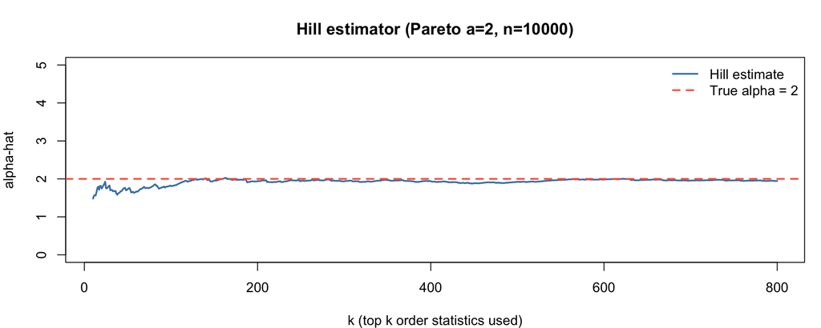

```r
hill_alpha <- function(x, k) {
  x_sorted <- sort(x, decreasing = TRUE)
  xi_hat   <- mean(log(x_sorted[1:k]) - log(x_sorted[k + 1]))
  1 / xi_hat
}

alpha_true <- 2
x_pareto   <- (1 - runif(10000))^(-1/alpha_true)

k_seq    <- 10:800
hill_est <- sapply(k_seq, function(k) hill_alpha(x_pareto, k))

par(mfrow = c(1, 1), mar = c(4, 4, 3.5, 1))
plot(k_seq, hill_est, type = "l", col = "steelblue", lwd = 2,
     main = paste0("Hill estimator (Pareto a=", alpha_true, ", n=10000)"),
     xlab = "k (top k order statistics used)", ylab = "alpha-hat",
     ylim = c(0, 5))
abline(h = alpha_true, col = "tomato", lwd = 2, lty = 2)
legend("topright", c("Hill estimate", paste0("True alpha = ", alpha_true)),
       col = c("steelblue", "tomato"), lwd = 2, lty = c(1, 2), bty = "n")
```

### 5.4.3 重尾的后果：矩的存在性

对 Pareto($\alpha$)，$k$ 阶矩存在当且仅当 $k < \alpha$。$\alpha \leq 1$ 时连均值都不存在。

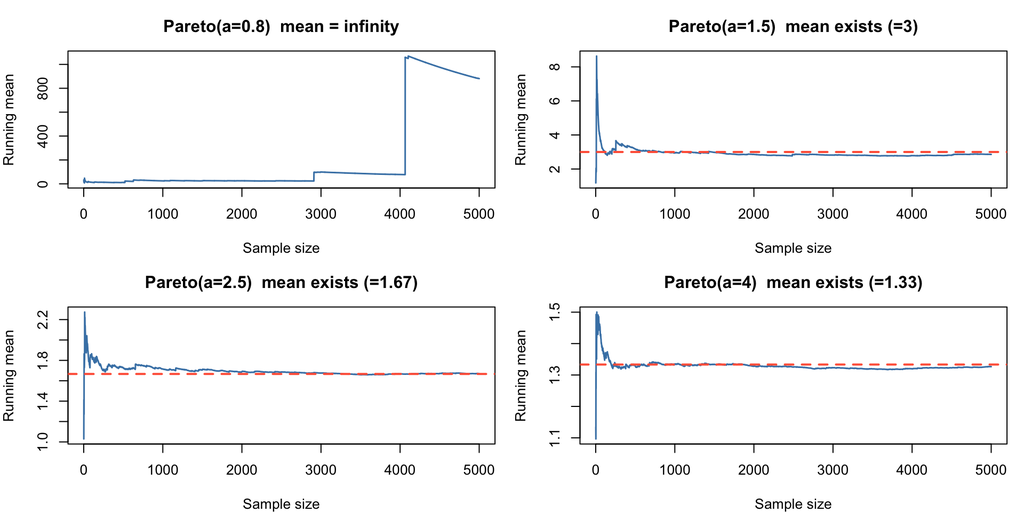

```r
alphas <- c(0.8, 1.5, 2.5, 4.0)
par(mfrow = c(2, 2), mar = c(4, 4, 3, 1))
for (alpha in alphas) {
  x_p      <- (1 - runif(5000))^(-1/alpha)
  cum_mean <- cumsum(x_p) / seq_along(x_p)
  plot(cum_mean, type = "l", col = "steelblue", lwd = 1.5,
       main = paste0("Pareto(a=", alpha, ")  ",
                     if (alpha > 1) paste0("mean exists (=", round(alpha/(alpha-1), 2), ")")
                     else "mean = infinity"),
       xlab = "Sample size", ylab = "Running mean")
  if (alpha > 1) abline(h = alpha/(alpha-1), col = "tomato", lwd = 2, lty = 2)
}
```

# 6 反推字典：看到分布，猜机制

前面每一节都是”给定机制 → 推出分布”。实际做数据时方向常常是反的：**先看到一个分布形状，想知道背后可能是什么过程**。把全文倒过来读，就是一张字典：

| 看到的分布 | 最可能的机制 | 怎么进一步验证 |
| --- | --- | --- |
| 正态 | 很多小量**相加**（加性累积、测量误差叠加） | 能否分解成独立分量之和；取对数后应当变歪 |
| 对数正态 | 很多因子**相乘**（比例增长、复利、逐次损耗） | **取对数后应当变成正态**（最快的一招） |
| 指数 | **无记忆等待**：恒定风险率下的首个事件 | 风险率是否随时间恒定；存活曲线在 lin-log 上是直线 |
| Gamma | $k$ 次无记忆等待的**累积**（等第 $k$ 个事件） | 是否天然是”第 $k$ 次到达”；$k$ 大时应趋于正态 |
| Poisson | 固定窗口内**数**稀有独立事件 | 方差是否 $\approx$ 均值（过离散则另有异质性） |
| Gumbel / Fréchet / Weibull | 取了很多量的**最大值**（纪录、洪水、最弱环节） | 数据本身是不是”每组的极值”；原始量的尾型决定落进哪一族 |
| 幂律 | **反馈**：优先增长／乘性+托底／临界分枝 | log-log 直线只是线索——须做严格拟合检验，并与对数正态、截断幂律对打 |
| Beta | 次序统计量（第 $k$ 小的位置）、比例型自我强化 | 是否本质是”比例”或”排序位置” |

**一句要紧的免责声明**：分布形状只能**缩小**机制假设的范围，不能唯一确定机制。同一个分布常有多条生成路径（对数正态既可由乘性增长得到，也可由别的变换得到；幂律至少有三种机制），而不同机制在有限样本上又可能给出几乎相同的形状。真正定案要靠**分布之外的信息**：时间序列的动态、变量之间的依赖结构、可操纵的实验干预。

# 7 收束：为什么分布就那么几个

回到最初的问题——为什么统计学里反复出现的分布只有那么几个？本文给的答案是：

**因为”很多小贡献合成一个量”的方式只有那么几种。**

$$\text{加} \to \text{正态} \qquad
\text{乘} \to \text{对数正态} \qquad \text{取最大} \to
\text{极值三族}$$

三个算子，三个极限定理。定理的力量在于**普适**：单个贡献长什么样几乎不重要，合成的结果都被吸引到同一族里去。所以自然界里那些看似无关的量，会一遍遍落回同一批形状。

而当合成过程里出现**反馈**——增长依赖当前规模、乘性涨落被托底、分裂恰好平衡在临界——独立同分布的前提就破了，三大定理失效，取而代之的是**幂律**：没有特征尺度、极端值远比直觉频繁。

一句话带走：**分布不是被发明的，是被”合成方式”选出来的；而幂律是反馈留下的指纹。**

# 8 附录：Gamma 和 Beta 为什么无处不在

这两个分布不是独立的机理，而是前面几种聚合的**自然数学延伸**。

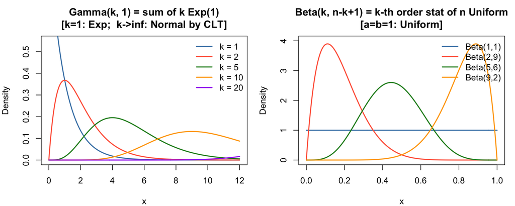

```r
par(mfrow = c(1, 2), mar = c(4, 4, 3.5, 1))

x_a  <- seq(0, 12, length.out = 400)
cols_a <- c("steelblue","tomato","forestgreen","orange","purple")

# Gamma = sum of k Exp
plot(NA, xlim = c(0, 12), ylim = c(0, 0.55),
     main = "Gamma(k, 1) = sum of k Exp(1)\n[k=1: Exp;  k->inf: Normal by CLT]",
     xlab = "x", ylab = "Density")
for (i in seq_along(c(1,2,5,10,20))) {
  k <- c(1,2,5,10,20)[i]
  lines(x_a, dgamma(x_a, shape = k, rate = 1), col = cols_a[i], lwd = 2)
}
legend("topright", paste("k =", c(1,2,5,10,20)), col = cols_a, lwd = 2, bty = "n")

# Beta = order statistic
x_b    <- seq(0, 1, length.out = 400)
params <- list(c(1,1), c(2,9), c(5,6), c(9,2))
plot(NA, xlim = c(0, 1), ylim = c(0, 4),
     main = "Beta(k, n-k+1) = k-th order stat of n Uniform\n[a=b=1: Uniform]",
     xlab = "x", ylab = "Density")
for (i in seq_along(params))
  lines(x_b, dbeta(x_b, params[[i]][1], params[[i]][2]), col = cols_a[i], lwd = 2)
legend("topright",
       sapply(params, function(p) paste0("Beta(", p[1], ",", p[2], ")")),
       col = cols_a[seq_along(params)], lwd = 2, bty = "n")
```

- **Gamma**：$k$ 个 Exp 之和。$k=1$ 是 Exp，$k \to \infty$ 由 CLT 趋向 Normal。Chi-squared 是 Gamma($k/2$, $1/2$) 的特例。
- **Beta**：$n$ 个 Uniform 的第 $k$ 小次序统计量。$\alpha=\beta=1$ 退化为 Uniform。

*Generated: 2026-07-25 21:49:48.234016*